# Snowflake and sparklyr

Couldn’t think of a more Christmassy blog post no? Sparkle your analysis with sparklyr and Snowflake(s)!!  
(Yes I know, bad joke, its the end of the year and I need a break alright!!)

> This blog post is going to be about hooking up your data connections using Snowflake and R, and playing with your larger (wink wink) datasets using the sparkle of sparklyr!!

To get started..  
**Snowflake** is a cloud data warehouse suited for big data storage and analysis. Look [here](https://www.snowflake.com/product/). For this post, Im assuming you have an account with Snowflake.  
**sparklyr** is an interface for R users to leverage the awesomeness of [Apache Spark](https://databricks.com/spark/about). [sparklyr](https://spark.rstudio.com/) lets you run your analysis and machine learning algorithms on very large datasets, that would ordinarily not fit into your local R instance’s memory.

The steps are relatively straightforward, but require reading quite a lot of documentation and might be a little complicated for someone starting out with either Snowflake or Apache Spark. I didn’t find any staightforward answers published online either so this might help.

### 1. Installations

| Technology | What to do |
| --- | --- |
| Snowflake JDBC driver | [Click here](https://search.maven.org/classic/#search%7Cgav%7C1%7Cg%3A%22net.snowflake%22%20AND%20a%3A%22snowflake-jdbc%22). |
| Snowflake Spark Connector | [Click here](https://search.maven.org/classic/#search%7Cga%7C1%7Ca%3A%22spark-snowflake_2.11%22). |
| R / RStudio | Click here |
| sparklyr | Install the ‘sparklyr’ package in R. |
| Apache Spark | Run *sparklyr::spark_install( version= “2.3.1” )* in R **once**. |

### 2. Set up Spark Home Env Variable

This is just setting up the enrionmental variable Spark$Home so that you could run spark commands from your terminal directly.

MacOSX users can edit their .bash_profile file and Windows Users can set thier environmental variables directly through the wizard. Your spark home should point to your spark installation, like mine was  
**“somepath/spark/spark-2.3.1-bin-hadoop2.7”**.  
Your Spark$Home variable string will depend on where you have installed it and the downloaded versions.

### 3. Configurations

Now you need to use your Snowflake JDBC driver and the Snowflake Spark Connector to configure your spark-shell (your local Apache Spark connection in this case).  
To do this navigate to your local spark installation bin folder and then run the following command.

It should look something like this.

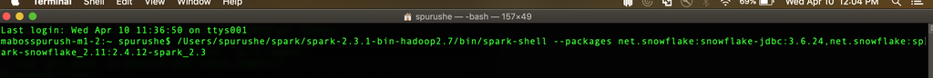

Make sure you get your Apache Spark version, Scala version, Snowflake JDBC driver version and Snowflake Spark Connector version according to your preferences. For more advanced details check [this](https://docs.snowflake.net/manuals/user-guide/spark-connector-install.html).

### 4. Lets code and test!

Ive commented most of the code below because it had sensitive login information.

```r
suppressPackageStartupMessages(library(sparklyr))
### Setting up config to connect to local mode of Spark

# conf = spark_config()
# conf$`sparklyr.cores.local`= 4
# conf$`sparklyr.shell.driver-memory` = "16G"
# conf$`sparklyr.shell.driver-class-path` = "/Library/Java/Extensions/snowflake-jdbc-3.6.12.jar"
# conf$`spraklyr.memory.fraction` = '0.6';
#
#
# sc = spark_connect(master = "local", version = '2.3.1', config = conf)
```

```r
## connection with Snowflake using the Snowflake Driver and Spark connector
## you have to configure ur Spark installation to connect to the Spark connector. TODO document the steps for this



#base_connection_string <- "jdbc:snowflake://your_account_name.snowflakecomputing.com/?account=your_account_name"

# opt = list(
#             url = base_connection_string
#             ,user = "snowflake_username"
#             ,password = "snowflake_password"
#             ,warehouse='snowflake_warehouse_name'
#             ,dbtable = "db.schema.your_table_in_Snowflake"
#             )


## importing the above table from SF into a Spark dataframe
## input_data is a remote tibble  >>  "tbl_spark" "tbl_sql"   "tbl_lazy"  "tbl"


 # input_data = sc %>%
 #          spark_read_jdbc(sc = ., name = "spark_df_name",
 #                          options = opt
 #                          , repartition = 0
 #                          , memory = FALSE
 #                          , overwrite = TRUE
 #                          )


 # input_data %>% tally()
```

> This should create the *spark_df_name* spark data frame on your local Spark, which can then be used for analysis, machine learning and much more.

The world is your oyster !! 👽